# fitbit Nike

Manes Munyanyi

18 July 2019

## Preparing the R environment

### Setting echo equal to TRUE and results equal to ‘hold’ as global options for this document so that someone else will be able to read the code.

```r
#Loading knitr library and setting echo equal to true
library(knitr)
opts_chunk$set(echo = TRUE, results = 'hold')
#Loading other required libraries
library(data.table)
# ggplot2 is the the packadge of choice for plotting figures
library(ggplot2)
```

# Synopsis

## The work is based on data from a personal activity monitoring device. The device collects data at a 5 minute interval throughout the day. The data is for an anonymous individual whaich was collected over a two month period of October and November in 2012.

## The objectives are to preprocess the data for analysis, plot graphs based number of steps done per 5 min interval, calculate the mean and median as well as add missing values

## Loading and preprocessing the data

### The data is loaded and preprocessed befor the actual processing. This includes reading the .csv file, formating the date among others

```r
#Reading data in actvity.csv and Transforming data to a format suitable for your analysis
ActivityData <- read.csv('C:/DataScience/RepResearch1/activity.csv', header = TRUE, sep = ",", colClasses=c("numeric", "character", "numeric"))

#The following set of code converts the date field to Date class and interval field to Factor class.
ActivityData$date <- as.Date(ActivityData$date, format = "%Y-%m-%d")
ActivityData$interval <- as.factor(ActivityData$interval)

#Checking the structure of data after preprocessing
head(ActivityData)
```

```
##   steps       date interval
## 1    NA 2012-10-01        0
## 2    NA 2012-10-01        5
## 3    NA 2012-10-01       10
## 4    NA 2012-10-01       15
## 5    NA 2012-10-01       20
## 6    NA 2012-10-01       25
```

### Calculating the mean total number of steps day

```r
dataStepsDays <- aggregate(steps ~ date, ActivityData, sum)
colnames(dataStepsDays) <- c("date","steps")
head(dataStepsDays)
```

```
##         date steps
## 1 2012-10-02   126
## 2 2012-10-03 11352
## 3 2012-10-04 12116
## 4 2012-10-05 13294
## 5 2012-10-06 15420
## 6 2012-10-07 11015
```

### Plotting a histogram of the total number of steps taken per day, plotted with appropriate bin interval

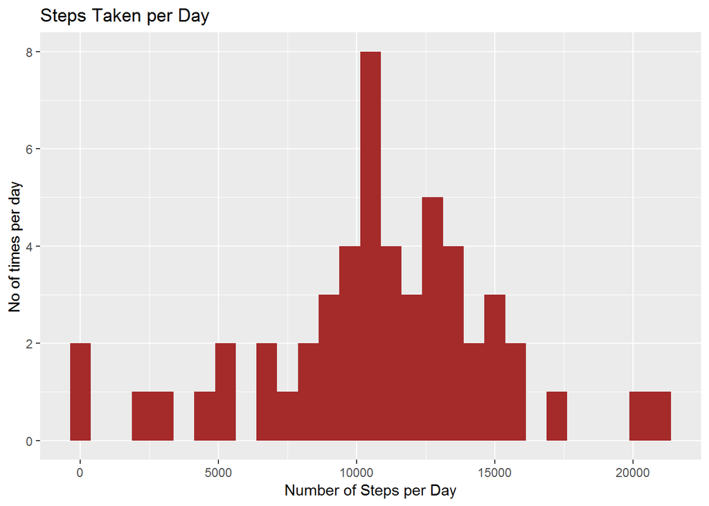

```r
#Plotting the histogram
ggplot(dataStepsDays, aes(x = steps)) +
       geom_histogram(fill = "brown", binwidth = 750) +
        labs(title="Steps Taken per Day",
             x = "Number of Steps per Day", y = "No of times per day")
```

## Calculating mean and median of number of steps taken per day

```r
#calculating mean
meanSteps   <- mean(dataStepsDays$steps, na.rm=TRUE)
meanSteps
#calculating median
medianSteps <- median(dataStepsDays$steps, na.rm=TRUE)
medianSteps
```

```
## [1] 10766.19
## [1] 10765
```

## Calculating the average daily activity pattern?

### This is achieved by aggregating the steps by at 5-minute interval and assigning the value to variable which is a data frame

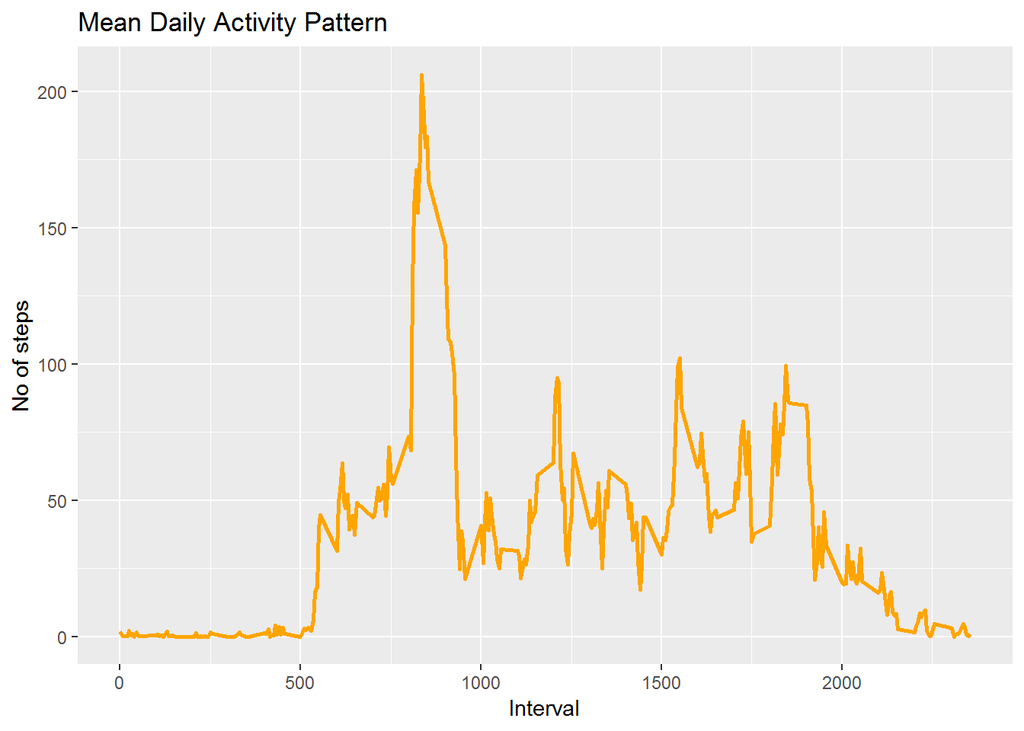

```r
dataStepsIntMean <- aggregate(ActivityData$steps,
                                by = list(interval = ActivityData$interval),
                                FUN=mean, na.rm=TRUE)
#converting values to integers
dataStepsIntMean$interval <-
        as.integer(levels(dataStepsIntMean$interval)[dataStepsIntMean$interval])
colnames(dataStepsIntMean) <- c("interval", "steps")

#Plotting time series of the average number of steps
ggplot(dataStepsIntMean, aes(x=interval, y=steps)) +
        geom_line(color="orange", size=1) +
        labs(title="Mean Daily Activity Pattern", x="Interval", y="No of steps")
```

## Finding the 5-minute interval with the maximum number of steps

```r
maxStepsInterval <- dataStepsIntMean[which.max(
        dataStepsIntMean$steps),]
maxStepsInterval
```

```
##     interval    steps
## 104      835 206.1698
```

## Fixing missing values:

### First Count missing values: Accomplished by using is.na() to check whether the value is missing then using sum to find the total missing values

```r
totalMissingValues <- sum(is.na(ActivityData$steps))
totalMissingValues
```

```
## [1] 2304
```

### Lastly, Replace all of the missing values in the dataset with the mean value at the same interval across days. This is accomplished by introducing a function where the data argument is ActivityData and pervalue argument is the dataStepsIntMean

```r
naReplace <- function(data, pervalue) {
        naIndex <- which(is.na(data$steps))
        naSub <- unlist(lapply(naIndex, FUN=function(idx){
                interval = data[idx,]$interval
                pervalue[pervalue$interval == interval,]$steps
        }))
        stepsReplace <- data$steps
        stepsReplace[naIndex] <- naSub
        stepsReplace
}
#filling of missing data by use of function
ActivityDataReplaced <- data.frame(
        steps = naReplace(ActivityData, dataStepsIntMean),
        date = ActivityData$date,
        interval = ActivityData$interval)
head(ActivityDataReplaced)
```

```
##       steps       date interval
## 1 1.7169811 2012-10-01        0
## 2 0.3396226 2012-10-01        5
## 3 0.1320755 2012-10-01       10
## 4 0.1509434 2012-10-01       15
## 5 0.0754717 2012-10-01       20
## 6 2.0943396 2012-10-01       25
```

### Checking for any missing values not input

```r
sum(is.na(ActivityDataReplaced$steps))
#Zero output means no missing values
```

```
## [1] 0
```

### Histogram of the total number of steps taken each day after replacing missing values

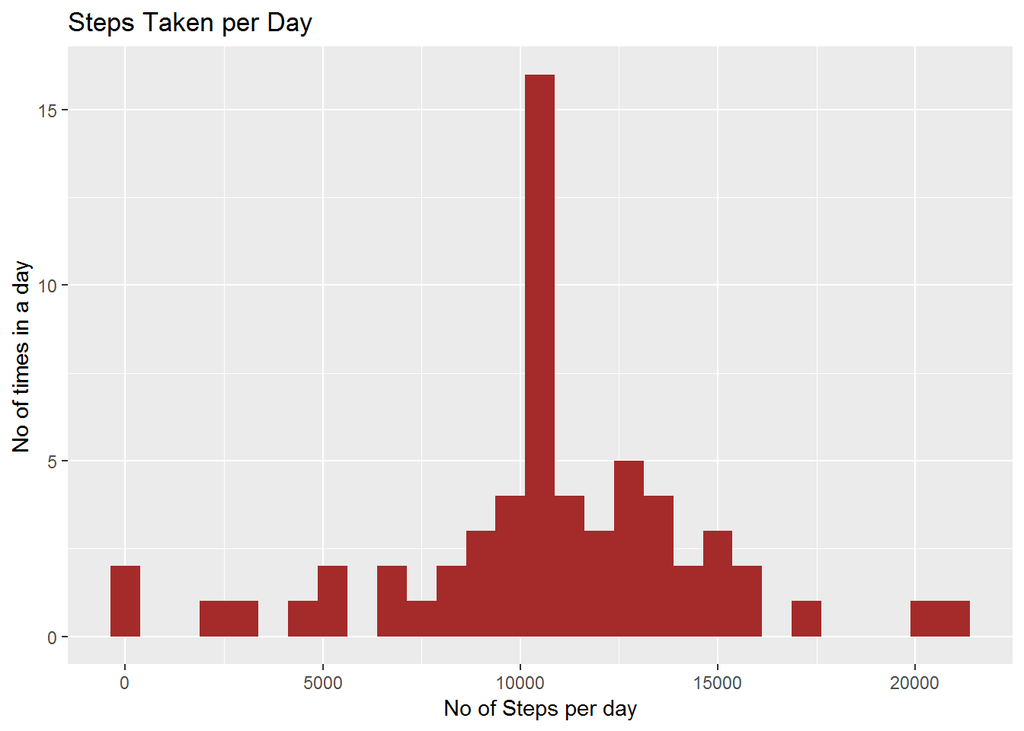

```r
replaceDataStepsDays <- aggregate(steps ~ date, ActivityDataReplaced, sum)
colnames(replaceDataStepsDays) <- c("date","steps")
##plotting the histogram

ggplot(replaceDataStepsDays, aes(x = steps)) +
       geom_histogram(fill = "brown", binwidth = 750) +
        labs(title="Steps Taken per Day",
             x = "No of Steps per day", y = "No of times in a day")
```

## Calculating the mean and median after replacing missing values

```r
#Calculating the mean number of steps per day
meanStepsReplaced   <- mean(replaceDataStepsDays$steps, na.rm=TRUE)
meanStepsReplaced
#Calculating the median number of steps per day
medianStepsReplaced <- median(replaceDataStepsDays$steps, na.rm=TRUE)
medianStepsReplaced
```

```
## [1] 10766.19
## [1] 10766.19
```

## Activity patterns between weekdays and weekends

### This is achieved by:

### First, Augmenting the data table with a column that indicates the day of the week

### Secondly, Subseting the data table into two sections namely weekdays and weekends.

### Thirdly, Put in a table the average steps per interval for each data set.

### Lastly, Plot the two charts one for weekdays and the other other fro weekends

```r
stepsDays <- function(data) {
    stepsDays <- aggregate(data$steps, by=list(interval = data$interval),
                          FUN=mean, na.rm=T)
    # convert to integers for plotting
    stepsDays$interval <-
            as.integer(levels(stepsDays$interval)[stepsDays$interval])
    colnames(stepsDays) <- c("interval", "steps")
    stepsDays
}

dataPerWeekdays <- function(data) {
    data$weekday <-
            as.factor(weekdays(data$date)) # weekdays
    weekendActivityData <- subset(data, weekday %in% c("Saturday","Sunday"))
    weekdayActivityData <- subset(data, !weekday %in% c("Saturday","Sunday"))

    stepsWeekend <- stepsDays(weekendActivityData)
    stepsWeekday <- stepsDays(weekdayActivityData)

    stepsWeekend$dayofweek <- rep("weekend", nrow(stepsWeekend))
    stepsWeekday$dayofweek <- rep("weekday", nrow(stepsWeekday))

    dataPerweekdays <- rbind(stepsWeekend, stepsWeekday)
    dataPerweekdays$dayofweek <- as.factor(dataPerweekdays$dayofweek)
    dataPerweekdays
}

dataWeekdays <- dataPerWeekdays(ActivityDataReplaced)
```

## Plots of average number of steps per 5 minute interval by Weekday and Weekend

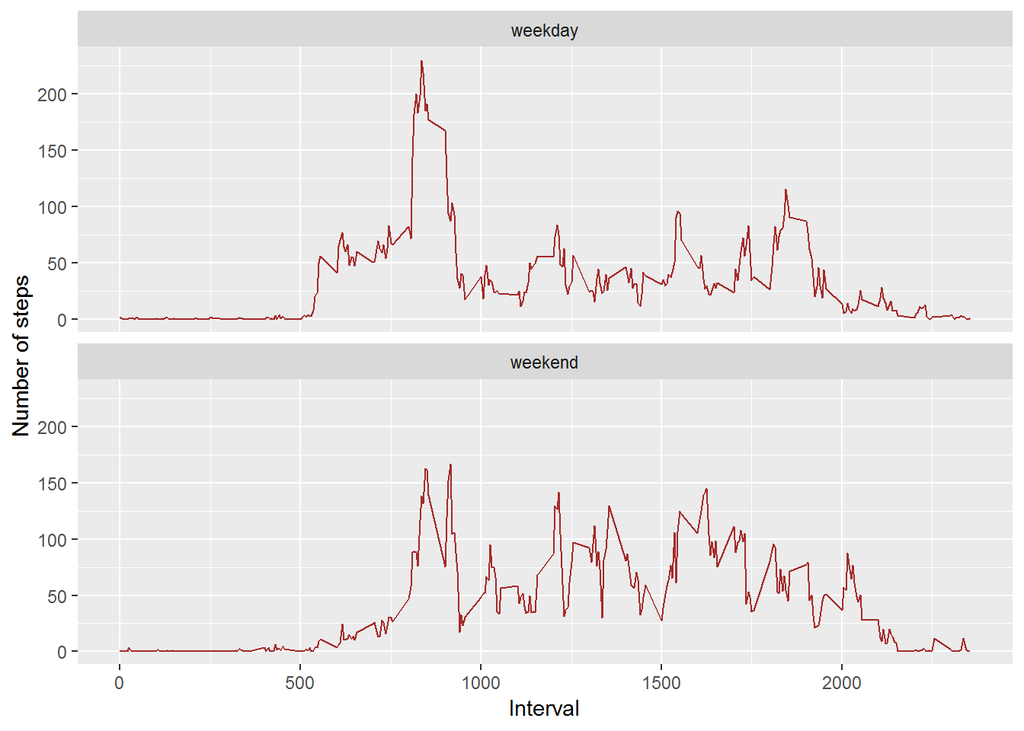

```r
ggplot(dataWeekdays, aes(x=interval, y=steps)) +
        geom_line(color="brown") +
        facet_wrap(~ dayofweek, nrow=2, ncol=1) +
        labs(x="Interval", y="Number of steps")
```